# Tutorial on Imbalanced Classification Tasks

Daniel Ranchal Parrado (danielranchal@correo.ugr.es)

January 29, 2022

This is an R Notebook a practical session on “Data Mining: Advanced Aspects” course from the “Master in Data Science and Computer Engineering” at University of Granada.

When you execute code within the notebook, the results appear beneath the code.

# Introduction

Any dataset with an unequal class distribution is technically imbalanced. However, a dataset is said to be imbalanced when there is a significant, or in some cases extreme, disproportion among the number of examples of each class of the problem. In other words, the class imbalance occurs when the number of examples representing one class is much lower than the ones of the other classes. Hence, one or more classes may be underrepresented in the dataset. Such a simple definition has brought along a lot of attention from researchers and practitioners due to the number of real-world applications where the raw data gathered fulfill this definition.

In this step-by-step tutorial you will:

1. Get the most useful packages for addressing imbalanced classification with machine learning in R.
2. Load a dataset and understand it’s structure using statistical summaries and data visualization.
3. Create several machine learning models in synergy with pre-processing techniques for imbalanced data, pick the best and build confidence that the predictive performance is reliable.

For the sake of easing this ``hands-on’’ session, the document contains chunks of R source code that can be run directly. Try executing this first chunk by clicking the *Run* button within the chunk or by placing your cursor inside it and pressing *Cmd+Shift+Enter* (*Ctrl+Shift+Enter* in Windows).

```r
print("Welcome to your first R NoteBook")
```

```
[1] "Welcome to your first R NoteBook"
```

If you like to a new chunk, just click the *Insert Chunk* button on the toolbar or by pressing *Cmd+Option+I* (or *Ctrl+Alt+I* in Windows). This way, you may add your own code if requested.

Here is an overview what we are going to cover in this *Tutorial on Imbalanced Classification*:

1. Installing the R platform.
2. Loading the dataset.
3. Summarizing the dataset.
4. Visualizing the dataset.
5. Evaluating some algorithms.
6. Comparison among different solutions.

Take your time. Work through each step.

Install Required Packages Install the packages we are going to use today. Packages are third party add-ons or libraries that we can use in R.

```r
install.packages(c("caret","dplyr","pROC","tidyr","imbalance", "markdown", "mime", "ellipse", "themis"))
```

**NOTE:** We may need other packages, but caret should ask us if we want to load them. If you are having problems with packages, you can install the caret packages and all packages that you might need by typing (remove the # character):

```r
#install.packages("caret", dependencies=c("Depends", "Suggests"),repos = "http://cran.r-project.org")
```

Now, let’s load the packages that we are going to use in this tutorial, the caret and imbalance packages, among others.

```r
library(caret)
library(imbalance) #to be used in the optional part
library(dplyr)
library(pROC)
library(tidyr)
library(ellipse)
library(ggvis)
```

As you might already know, the caret package provides a consistent interface into hundreds of machine learning algorithms and provides useful convenience methods for data visualization, data resampling, model tuning and model comparison, among other features. It’s a must have tool for machine learning projects in R.

One of its advantages for the use of caret is that it directly integrates the use of pre-processing techniques when setting up the control method for the training stage.

For more information about the caret R package see the [caret package homepage](http://topepo.github.io/caret/index.html).

# Step One. Get your data

For the sake of establishing a controlled scenario, we will make use of two different artificial data, namely the “circle” and “subclus” data, which can be found in different studies on imbalanced classification. These are binary problems, both in terms of attributes and classes.

In addition, we can load some data from the imbalance package, such as the glass0 one (see [Kaggle](https://www.kaggle.com/uciml/glass)). In this case, we can observe the behavior of the different methods on a real case study.

Here is what we are going to do in this step:

0. Load the glass0 data the easy way (with imbalance package). This will only serve for the individual tasks to be accomplished afterwards.
1. Load the circle data from CSV (optional, for purists).
2. Separate the data into a training dataset and a validation dataset.

For the “subclus” data, please follow the same procedure as in the case of “circle”.

the imbalance package provides the glass0 dataset for us, among others. Load the dataset as follows:

```r
# attach the glass0 dataset to the environment
data(glass0)
# rename the dataset
glassDataset <- glass0
```

I like to name the loaded data “dataset”. This is helpful if you want to copy-paste code between projects and the dataset always has the same name.

Load From CSV In the case you have previously downloaded the dataset, you may want to load the data just from a CSV file.

1. Download the circle (and subclus) dataset from PRADO (UGR).
2. Save the file as circle.csv (and subclus) in your project directory.
3. Load the dataset from the CSV file as follows:

```r
# load the CSV file from the local or web directory
dataset <- read.csv("data/circle.csv", header = TRUE)
# set the column names in the dataset (you must know them a priori)
colnames(dataset) <- c("Att1", "Att2", "Class")
dataset$Class <- relevel(factor(dataset$Class), "positive") #to ensure it appears at the first class
```

You now have the circle data loaded in R and accessible via the dataset variable.

# Step Two. Know your data: Summarize Dataset

Now it is time to take a look at the data.

In this step we are going to take a look at the data a few different ways:

1. Dimensions of the dataset.
2. Types of the attributes.
3. Peek at the data itself.
4. Levels of the class attribute.
5. Breakdown of the instances in each class.
6. Statistical summary of all attributes.

Don’t worry, each look at the data is one command. These are useful commands that you can use again and again on future projects.

## Dimensions of Dataset

We can get a quick idea of how many instances (rows) and how many attributes (columns) the data contains with the dim function.

```r
# dimensions of dataset
dim(dataset)
```

```
[1] 2390    3
```

You should see 2390 instances and 3 attributes in the case of the “circle” data.

## Types of Attributes

It is a good idea to get an idea of the types of the attributes. They could be doubles, integers, strings, factors and other types.

Knowing the types is important as it will give you an idea of how to better summarize the data you have and the types of transforms you might need to use to prepare the data before you model it.

In this example, you should see that all of the inputs are double and that the class value is a factor.

```r
# Check the structure and type of each attribute
str(dataset)
```

```
'data.frame':   2390 obs. of  3 variables:
 $ Att1 : num  248 229 229 312 300 ...
 $ Att2 : num  222 219 221 238 254 ...
 $ Class: Factor w/ 2 levels "positive","negative": 1 1 1 1 1 1 1 1 1 1 ...
```

## Peek at the Data

It is also always a good idea to actually eyeball your data. You should see the first 5 rows of the data:

```r
# take a peek at the first 5 rows of the data
head(dataset)
```

|  | Att1 | Att2 | Class |
| --- | --- | --- | --- |
| 1 | 248.2755 | 221.7979 | positive |
| 2 | 228.5710 | 218.6520 | positive |
| 3 | 228.6188 | 220.5286 | positive |
| 4 | 311.8650 | 238.2219 | positive |
| 5 | 300.3109 | 253.5445 | positive |
| 6 | 309.0332 | 247.3192 | positive |

## Levels of the Class

The class variable is a factor. A factor is a class that has multiple class labels or levels. Let’s look at the levels. Notice how we can refer to an attribute by name as a property of the dataset. In the results we can see that the class has 2 different labels:

```r
# list the levels for the class
levels(dataset$Class)
```

```
[1] "positive" "negative"
```

This is a binary classification problem.

## Statistical Summary

Now finally, we can take a look at a summary of each attribute.

This includes the mean, the min and max values as well as some percentiles (25th, 50th or media and 75th e.g. values at this points if we ordered all the values for an attribute). We can see here the uneven distribution among classes: 2335 vs. 55 (circle data). This is confirmed by computing the Imbalanced Ratio (IR).

```r
# summarize attribute distributions
summary(dataset)
```

```
      Att1              Att2               Class
 Min.   :  4.442   Min.   :  0.5926   positive:  55
 1st Qu.:118.820   1st Qu.:118.3459   negative:2335
 Median :254.135   Median :249.1955
 Mean   :254.997   Mean   :253.1674
 3rd Qu.:389.010   3rd Qu.:389.8631
 Max.   :508.239   Max.   :505.8055
```

```r
imbalanceRatio(dataset)
```

```
[1] 0.0235546
```

# Visualize Dataset

We now have a basic idea about the data. We need to extend that with some visualizations.

We are going to look at two types of plots:

1. Univariate plots to better understand each attribute.
2. Multivariate plots to better understand the relationships between attributes.

## Univariate Plots

We start with some univariate plots, that is, plots of each individual variable.

It is helpful with visualization to have a way to refer to just the input attributes and just the output attributes. Let’s set that up and call the inputs attributes x and the output attribute (or class) y.

```r
# split input and output
x <- dataset[,1:2]
y <- dataset[,3]
```

Given that the input variables are numeric, we can create box and whisker plots of each. This gives us a much clearer idea of the distribution of the input attributes:

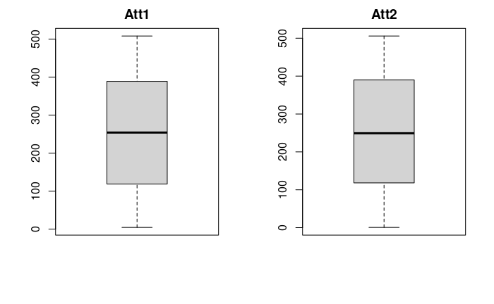

```r
# boxplot for each attribute on one image
par(mfrow=c(1,2))
  for(i in 1:2) {
  boxplot(x[,i], main=names(dataset)[i])
}
```

We can also create a barplot (better a pie chart) of the class variable to get a graphical representation of the class distribution. This confirms what we learned in the last section, that the instances are unevenly distributed across the two classes.

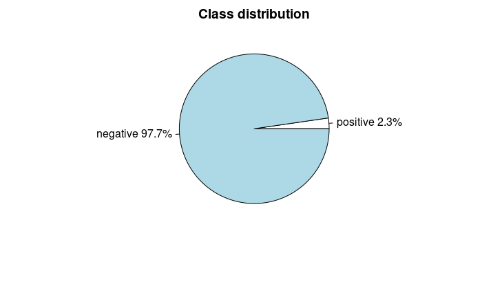

```r
# barplot for class breakdown
# plot(y)

# A pie chart is best
n_classes <- c(sum(y=="positive"), sum(y=="negative"))
pct <- round(n_classes/sum(n_classes)*100,digits=2)

lbls <- levels(dataset$Class)
lbls <- paste(lbls, pct) # add percents to labels
lbls <- paste(lbls,"%",sep="") # ad % to labels

pie(n_classes,labels = lbls, main="Class distribution")
```